# Oil and Economics

Ethan Van De Water, Maximo Gonzalez, Alex Nichols

12/13/23

# Intro

The world runs on energy, and for the last 2 centuries, a major source of the worlds energy has been oil. Historically, it has been an incredibly profitable industry. Today, oil and gas provide [80%](https://www.energy.gov/articles/economic-impact-oil-and-gas#:~:text=Lower%20energy%20costs%2C%20driven%20by,energy%20in%20the%20United%20States.) of American energy, and provide >12 million American jobs. A similar trend is followed globally, with few exceptions. As a result of the prominence of oil and gas within each nation-state’s energy consumption profile, it is a sought after commodity. Many conflicts both prior and current revolve around, or have implications relating to access to energy resources. A period specific example would be the most recent outbreak of the Russia-Ukraine war, beginning in February 2022. As a result of the re-kindling of this conflict, many European nations that were formerly served by Russian oil/gas had to find new sources of energy, as it was no longer an option to purchase from Russia given the nation’s encroachment upon Ukraine’s sovereignty.

This blog will provide further analysis of the impact that global conflicts have on the movement of energy resources, the price of energy resources, and the subsequent increases of prices for consumers.

# Content

## Word Search

First, we employed two approaches of sentiment analysis on news articles to explore the impact of global conflict on oil. We sought out articles relating to a series of key words that are relevant to our topic of interest (oil). These articles were found through using a few different key word searches such as: “Israel-Gaza Conflict”, “Global Macroeconomic Environment”, “Economic Impact of war” and “How war impacts national economies”. After performing these searches, we selected articles that had recent publication dates. We took care to include articles from different institutions such as Governments/National Banks, News Media groups, and high ranking individuals in the private sector. First, we explored the most used words across the articles.

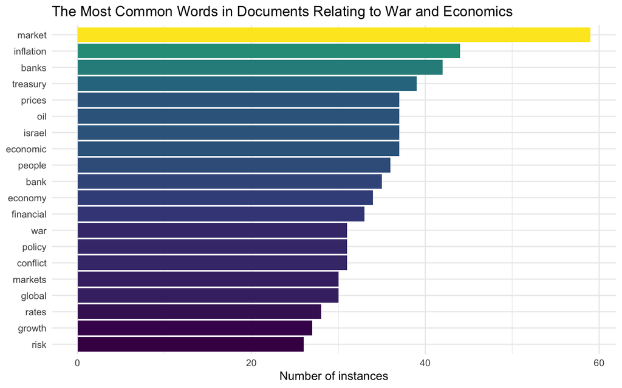

The output of this analysis gave us insight into the sentiment of the media, national governments, as well as the private sector. Obviously, an article from Bloomberg is going to be more likely to contain the words ‘inflation’ ‘market’ or ‘economy’ than an Emily Dickinson Poem, but seeing the other words that also appear in tandem with the aforementioned and viewing the output holistically still gives us a unique takeaway. That is: among all these economy related terms - oil is also a frequent topic. To confirm these results, and explore hidden intricacies, our second approach employed OpenAI’s ChatGPT ability to identify the key points in each article.

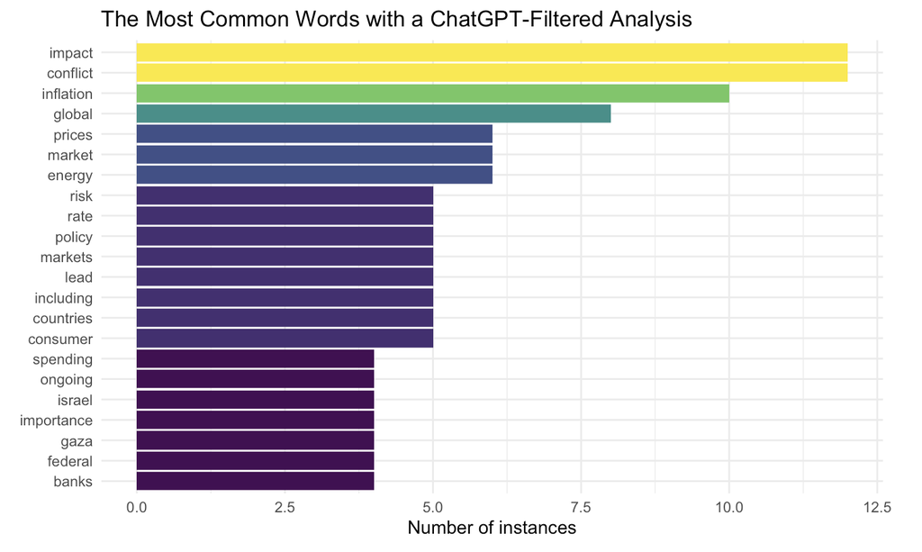

[figure not shown]

Federal Reserve Chair [Jerome Powell](https://www.federalreservehistory.org/people/jerome-h-powell) speaks on raising the benchmark Fed Funds Rate, which impacts the price of borrowing for financial institutions and eventually, consumers as well.

## Importing & Exporting Nations

The movement of oil across the globe is fascinating. Although some nations have the ability to be energy self-sufficient, much international trade still occurs. One group of nations that is often involved in the trade of oil is known as the Organization of the Petroleum Exporting Countries, or [(OPEC)](https://www.opec.org/opec_web/en/about_us/23.htm) for short. These nations engage in trade both with each other and with non-member nations. They do so with the goal of stabilizing the oil markets to ensure a consistent supply of petroleum to those who require it. The following visualizations show the volumes of crude oil imported and exported in two different years using spatial data. The units are in 1000s of barrels per day, where 1 barrel is roughly 42 US gallons.

### Oil Imports

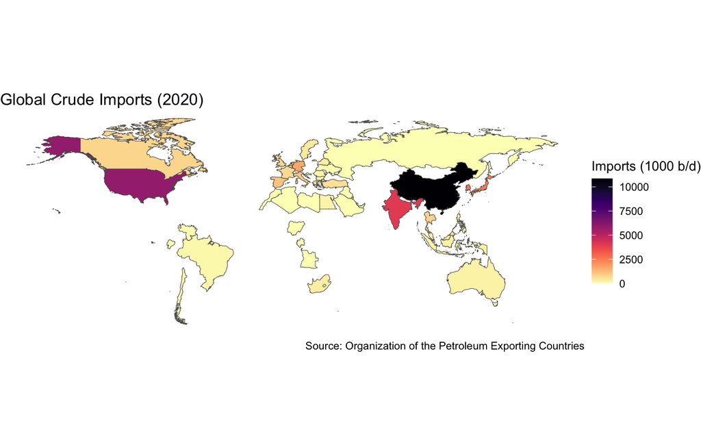

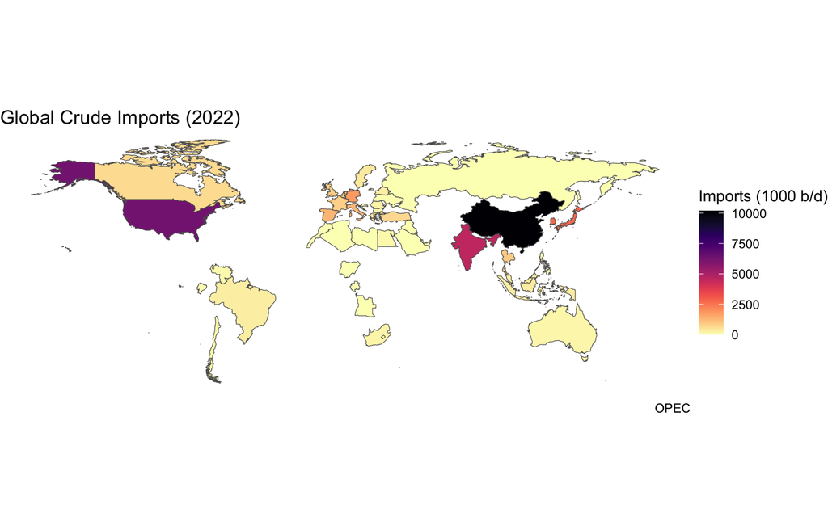

### Oil Exports

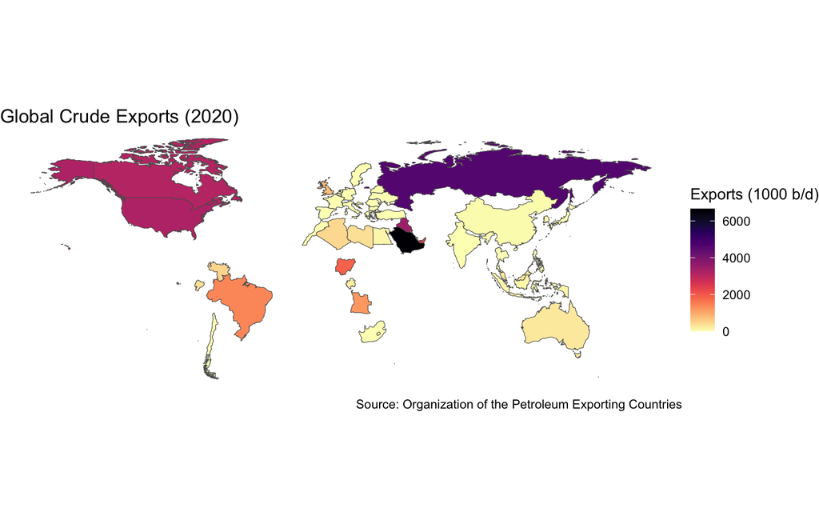

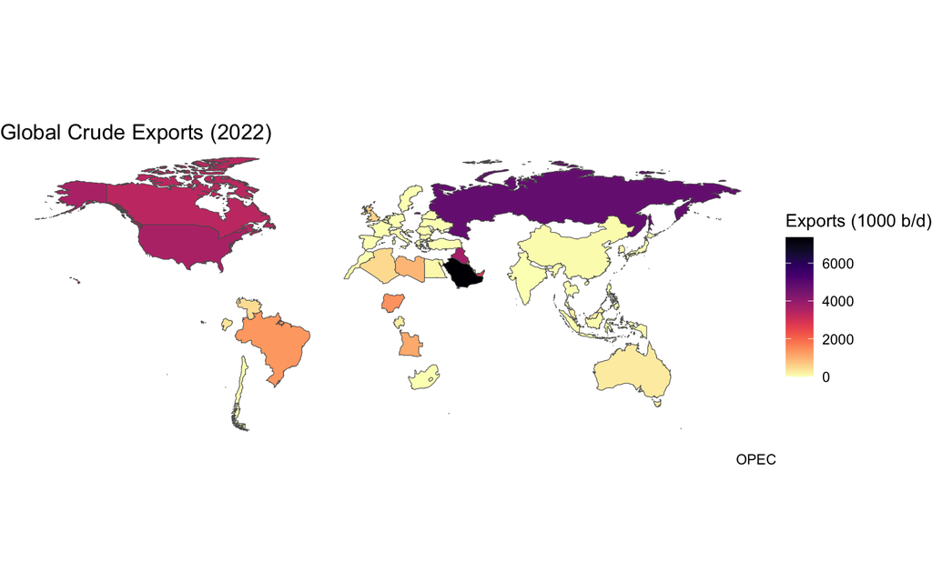

## Import & Export Data Table

Search this table to find discrete values for imports and exports of different nations and groups of nations. Individual years can also be searched. The units for imports/exports are 1000 b/d (thousands of barrels per day).

| Country | Year | Imports | Exports |
| --- | --- | --- | --- |
| OECD Americas | 1980 | 5882.397150684931 | 1412.867726027397 |
| OECD Americas | 1981 | 4958.9 | 1616.447424657534 |
| OECD Americas | 1982 | 3859.227506849315 | 2133.017808219178 |
| OECD Americas | 1983 | 3618.906904109589 | 2191.180383561644 |
| OECD Americas | 1984 | 3715.852893561644 | 2199.350219178083 |
| OECD Americas | 1985 | 3528.681561643836 | 2234.566246575343 |
| OECD Americas | 1986 | 4586.930876712328 | 2062.72904109589 |
| OECD Americas | 1987 | 5132.930767123287 | 2183.989260958904 |
| OECD Americas | 1988 | 5636.756963835616 | 2225.101753424657 |
| OECD Americas | 1989 | 6420.367671232877 | 2099.916219178082 |

[output cut: 2785 more lines]

## Oil Pricing

As previously mentioned, for nations such as the United States, the amount of oil that is imported or exported may be dependent on the prices of the commodity in different markets. The visualization below shows the differences in the price of a barrel of crude oil month to month in both the European and US markets.

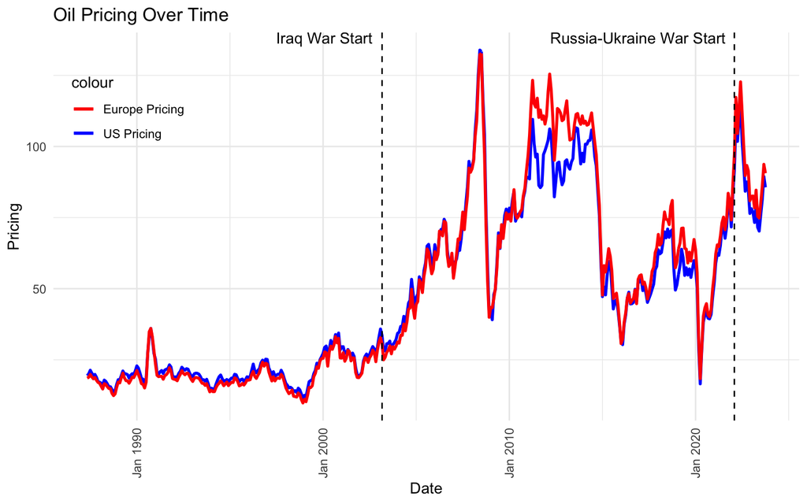

Over the years, oil pricing has been significantly influenced by key geopolitical moments. From large scale conflicts to geopolitical shifts, the plot reflects on how world events impact the oil market. Vertical dashed lines mark pivotal occasions, such as the onset of the Russia-Ukraine War in February 2022 and the Iraq War in March 2003. This visualization serves as a concise yet insightful purpose: illustrating the relationship between geopolitical happenings and the fluctuations in oil prices.

## CPI Background

We know that oil prices fluctuate. How does this impact the average American day to day? Probably the most salient impact of the volatility of oil prices is gasoline prices in the United States. With gasoline, there is a very straightforward series of connections from the price of oil increasing to the price at the pump increasing when one goes to fill their car up with gas. However, the impact that rising oil prices have on the cost of other goods may be less obvious. For example, goods that are shipped from China to the West Coast, and then subsequently trucked across the country may end up being more expensive as a result of the rising input costs for logistics companies. Logistics companies are paying more in fuel to bring goods places, and passing that cost onto the firm who contracts them. Then, that firm is passing the increased cost of transportation onto the consumer by way of increased prices for the particular set of goods they provide. As you can probably guess, these impacts can be difficult to quantify.

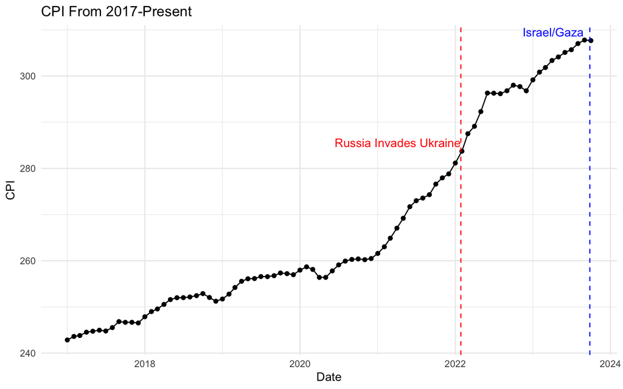

# Conclusion

The analysis that we performed within this project was illuminating. It was surrounding a topic each of us knew to be important, but actually knew very little about. The fact that the lights turn on, water runs, phones charge, all happen as a result of the production and usage of energy. In first world nations like the US, it is often taken for granted. Thus, doing a deeper dive into oil, which is still the predominant source of energy for many nations, was very interesting. It allowed us to discover the complexity and volatility of the global market for the commodity, as well as investigate how said volatility impacts citizens on a day to day basis.

Fortunately, when we were conducting our project we did not have much difficulty finding data. The oil industry is well regulated by government organizations and because it is such a valuable industry at the global scale, it is advantageous for companies and groups to collect lots of data. The majority of our quantitative data came from government websites, or international organizations such as OPEC. We also used text as data, which was easily accessible.

During our analysis, we explored which countries export/import the most oil, what oil prices have looked like over time, and tried to connect the prices of oil to the consumer price index for American Consumers. Our visualizations for exports/imports and oil prices were straight forward and easy to interpret. We ran into trouble when attempting to connect oil prices and CPI. This is where our analysis is most limited. We cannot make any concrete statements about the connections between them. Companies have entire business units delegated to the task of predicting how input prices will impact overall costs, and we did not have the tools nor the data to create a proper predictive model of any significance. However, we did our best to explain the issue we had within the given context

If we had to continue our exploration of the oil industry, there are a few areas that would be interesting to explore. One, if we were able to find data on exactly where oil is imported from/exported to, a network could be created. This would be a very cool way to showcase exactly where oil comes from, and where it goes. We could possibly also find data on shipping lanes and see, similar to flight patterns, what paths those massive container ships take when traversing oceans. Next, getting a more concrete idea of what goes into the CPI and possibly interviewing someone who has more knowledge on it than us would provide useful context for the reader. Lastly, doing an investigation into where energy is going in the future. Oil is a non-renewable source of energy, and governments are doing everything they can to prevent the continued use of fossil fuels globally and slow the effects of climate change. Looking at things like carbon credits, wind/solar energy, and nuclear energy would be cool avenues to look at in the future.

# References

Sources:

Ma, Dorothy, and Alice Huang. “Evergrande under Pressure in Hong Kong Court to Repay Creditors.” Bloomberg.Com, Bloomberg, 28 Nov. 2023, www.bloomberg.com/news/features/2023-11-28/evergrande-under-pressure-in-hong-kong-court-to-repay-creditors.

Jeffrey Feltman, Sharan Grewal, et al. “The Israel and Gaza War: Economic Repercussions.” Brookings, 24 Oct. 2023, www.brookings.edu/articles/the-israel-and-gaza-war-economic-repercussions/.

Mena, Bryan. “Israel-Hamas War Risks Further Deglobalization and Inflation | CNN Business.” CNN, Cable News Network, 15 Oct. 2023, www.cnn.com/2023/10/15/economy/stocks-week-ahead-deglobalization/index.html.

“Defense Department Continues to Stress Law of War with Israel.” U.S. Department of Defense, www.defense.gov/News/News-Stories/Article/Article/3578196/defense-department-continues-to-stress-law-of-war-with-israel/. Accessed 5 Dec. 2023.

Smith, Elliot. “Goldman Sachs Says the Israel-Hamas War Could Have Major Implications for Europe’s Economy.” CNBC, CNBC, 7 Nov. 2023, www.cnbc.com/2023/11/03/goldman-says-israel-hamas-war-could-majorly-impact-europes-economy.html.

“CNBC Exclusive: CNBC TRANSCRIPT: JPMorgan Chase Chairman & CEO Jamie Dimon Speaks with CNBC’s Leslie Picker on ‘Power Lunch’ Today.” CNBC, CNBC, 2 Aug. 2023, www.cnbc.com/2023/08/02/cnbc-exclusive-cnbc-transcript-jpmorgan-chase-chairman-ceo-jamie-dimon-speaks-with-cnbcs-leslie-picker-on-power-lunch-today.html.

“2023 Economic Outlook: Insights & Trends [Midyear Update].” 2023 Economic Outlook: Insights & Trends [Midyear Update], J.P. Morgan Chase, 8 Dec. 2022, www.jpmorgan.com/insights/outlook/economic-outlook/economic-trends.

“Testimony by Chair Powell on the Semiannual Monetary Policy Report to the Congress.” Board of Governors of the Federal Reserve System, www.federalreserve.gov/newsevents/testimony/powell20230621a.htm. Accessed 5 Dec. 2023.

“Speech by Vice Chair for Supervision Barr on Financial Stability.” Board of Governors of the Federal Reserve System, www.federalreserve.gov/newsevents/speech/barr20231116a.htm. Accessed 5 Dec. 2023.

Rappeport, Alan, and Patricia Cohen. “Fragile Global Economy Faces New Crisis in Israel-Gaza War.” The New York Times, The New York Times, 10 Oct. 2023, www.nytimes.com/2023/10/10/business/economy/global-economy-israel-gaza-war.html.

“CPI Home.” U.S. Bureau of Labor Statistics, U.S. Bureau of Labor Statistics, www.bls.gov/cpi/. Accessed 5 Dec. 2023.

The Economic Benefits of Oil & Gas - Department of Energy, www.energy.gov/articles/economic-impact-oil-and-gas. Accessed 12 Dec. 2023.

“What Is the Connection between the Price of Oil and Inflation?” DW Energy Group, 19 Jan. 2023, www.dwenergygroup.com/what-is-the-connection-between-the-price-of-oil-and-inflation/#:~:text=The%20correlation%20of%20oil%20to%20the%20Consumer%20Price%20Index%20(CPI)&text=A%20surge%20in%20the%20prices%20of%20oil%20can%20increase%20the,passed%20on%20to%20their%20consumers.

“OPEC” OPEC, www.opec.org/opec_web/en/. Accessed 12 Dec. 2023.

Martin, Tillier. “America Produces Enough Oil to Meet Its Needs, so Why Do We Import Crude?” Nasdaq, www.nasdaq.com/articles/america-produces-enough-oil-to-meet-its-needs-so-why-do-we-import-crude#:~:text=That%20happens%20because%20of%20a,cheaper%20than%20domestically%2Dproduced%20crude. Accessed 12 Dec. 2023.

With special thanks to OpenAI’s ChatGPT.